# Ecological Archives E093-083-metadata

*Ecological Archives* E093-083-D1

**Martha M. Ellis, Jennifer L. Williams, Peter Lesica, Timothy J. Bell, Paulette Bierzychudek, Marlin Bowles, Elizabeth E. Crone, Daniel F. Doak, Johan Ehrlén, Albertine Ellis-Adam, Kathryn McEachern, Rengaian Ganesan, Penelope Latham, Sheila Luijten, Thomas N. Kaye, Tiffany M. Knight, Eric S. Menges, William F. Morris, Hans den Nijs, Gerard Oostermeijer, Pedro F. Quintana-Ascencio, J. Stephen Shelly, Amanda Stanley, Andrea Thorpe, Tamara Ticktin, Teresa Valverde, and Carl Weekley. 2012. Matrix population models from 20 studies of perennial plant populations. *Ecology* 93:951.**

**INTRODUCTION**

Demographic matrix models are some of the most commonly used population models in both basic and applied ecological research (Caswell 2001, Morris and Doak 2002). Matrix models integrate data on individual demographic rates, such as age and/or stage specific birth and death rates, into descriptions of population level dynamics. These models have been used for a wide variety of applications: for example, to make inferences about the drivers of population growth (Crouse et al. 1987, Angert 2006, Marrero-Gomez et al. 2007), understand population level consequences of smaller scale experimental results (Shea and Kelly 1998, Williams et al. 2010), compare the effects of different sources of variability in population dynamics (Buckley et al. 2010), identify research priorities (Menges 2000), and provide guidance for developing management strategies (Lande 1988, Shea and Kelly 1998, Forsyth 2002, Coulson et al. 2004, Abrams 2005).

The relatively simple structure of these models, along with easily interpretable summary statistics such as population growth rates and sensitivity analyses, make it possible to apply very similar methods across a wide variety of taxa (Morris and Doak 2002, Salguero-Gomez and de Kroon 2010). As more models are published, these features have opened the door for multispecies comparisons. For example, Pfister (1998) and Franco and Silvertown (2004) compared elasticity patterns across species with varying life histories; Buckley et al. (2010) investigated patterns in variability among populations and species; and Stott et al. (2010) have compared transient dynamics of models based on different matrix and species traits.

Multi-year and site studies are particularly valuable because they provide within species comparisons, in addition to comparisons across species. By their very nature, long-term studies are rare because they require long-term commitment to maintain sites, consistent revisits, and continuous funding. However, these studies reveal important subtleties about a species that may be hidden in short-term, intensive studies (Menges 2000). Most multispecies comparisons of population dynamics have been based on a single mean matrix for describing a species (Franco and Silvertown 2004, Salguero-Gómez and Casper 2010, Stott et al. 2010); however, considering variation both within a population over time and among populations may yield a more thorough representation of patterns (Ramula et al. 2009, Buckley et al. 2010, Jongejans et al. 2010).

**METADATA**

**CLASS I. DATA SET DESCRIPTORS**

**A. Data set identity**: Demographic modeling results for plant populations: original matrix models, observed stage structures, and observed stage structures from a revisit between 5 and 18 years after the original study period.

**B. Data set identification code**

**C. Data set description:**

Authors/Data compilers:

> Martha M. Ellis  
> Wildlife Biology Program, College of Forestry and Conservation, University of Montana, Missoula, MT 59812 USA

> Jennifer L. Williams  
> National Center for Ecological Analysis and Synthesis, 735 State Street, Suite 300, Santa Barbara, CA 93101 USA

> Peter Lesica  
> Division of Biological Sciences, University of Montana, Missoula, MT 59812 USA

> Timothy J. Bell  
> Department of Biological Sciences, Chicago State University, 9501 S King Dr., Chicago IL 60628 USA

> Paulette Bierzychudek  
> Biology Department, Lewis and Clark College, 0615 S.W. Palatine Hill Rd, Portland, OR 97219 USA

> Marlin Bowles  
> The Morton Arboretum, 4100 Illinois Route 53, Lisle, IL 60532 USA

> Elizabeth E. Crone  
> Harvard University, Harvard Forest, 324 North Main Street, Petersham, MA 01366 USA

> Daniel F. Doak  
> Department of Zoology and Physiology, University of Wyoming, Laramie, WY 82071 USA

> Johan Ehrlén  
> Department of Botany, Stockholm University, SE-106 91 Stockholm, Sweden

> Albertine Ellis-Adam  
> Institute for Biodiversity and Ecosystem Dynamics, University of Amsterdam, Science Park 904, 1098 XH, Amsterdam, The Netherlands

> Kathryn McEachern  
> USGS-BRD-WERC, Channel Islands Field Station, 1901 Spinnaker Dr, Ventura, CA 93001 USA

> Rengaian Ganesan  
> Ashoka Trust for Research in Ecology and the Environment (ATREE), Royal Enclave, Sriramapura, Jakkur Post, Bangalore 560064, India

> Penelope Latham  
> National Park Service, Pacific West Region, 909 First Avenue, Seattle, WA 98104 USA

> Sheila Luijten  
> Institute for Biodiversity and Ecosystem Dynamics, University of Amsterdam, Science Park 904, 1098 XH, Amsterdam, The Netherlands

> Thomas N. Kaye  
> Institute for Applied Ecology, PO Box 2855, Corvallis, OR 97339 USA

> Tiffany M. Knight  
> Department of Biology, Washington University in St. Louis, One Brookings Drive, Box 1137, St. Louis, MO 63130 USA

> Eric S. Menges  
> Archbold Biological Station, P.O. Box 2057, Lake Placid, Florida 33862 USA

> William F. Morris  
> Biology Department, Duke University, Box 90338 Durham, NC 27708 USA

> Hans den Nijs  
> Institute for Biodiversity and Ecosystem Dynamics, University of Amsterdam, Science Park 904, 1098 XH, Amsterdam, The Netherlands

> Gerard Oostermeijer  
> Institute for Biodiversity and Ecosystem Dynamics, University of Amsterdam, Science Park 904, 1098 XH, Amsterdam, The Netherlands

> Pedro F. Quintana-Ascencio  
> Department of Biology, University of Central Florida, 4000 Central Florida Blvd., Orlando, FL 32816 USA

> J. Stephen Shelly  
> U.S. Forest Service, Region 1, P.O. Box 7669, Missoula, MT 59807 USA

> Amanda Stanley  
> Institute for Applied Ecology, PO Box 2855, Corvallis, OR 97339 USA

> Andrea Thorpe  
> Institute for Applied Ecology, PO Box 2855, Corvallis, OR 97339 USA

> Tamara Ticktin  
> Botany Department, University of Hawai`i at Manoa, 3190 Maile Way, Honolulu, HI 96822 USA

> Teresa Valverde  
> Departamento de Ecología y Recursos Naturales, Facultad de Ciencias, Universidad Nacional Autónoma de México, Ciudad Universitaria, México D.F., 04510 México

> Carl Weekley  
> Archbold Biological Station, PO Box 2057, Lake Placid, FL 33862 USA

**Abstract:** Demographic transition matrices are one of the most commonly applied population models for both basic and applied ecological research. The relatively simple framework of these models and simple, easily interpretable summary statistics they produce have prompted the wide use of these models across an exceptionally broad range of taxa. Here, we provide annual transition matrices and observed stage structures/population sizes for 20 perennial plant species which have been the focal species for long-term demographic monitoring. These data were assembled as part of the ‘Testing Matrix Models’ working group through the National Center for Ecological Analysis and Synthesis (NCEAS). In sum, these data represent 82 populations with >460 total population-years of data. It is our hope that making these data available will help promote and improve our ability to monitor and understand plant population dynamics.

**D. *Key words***: *conservation; Demographic matrix models; ecological forecasting; extinction risk; matrix population models; plant population dynamics; population growth rate**.*

**CLASS II.** **RESEARCH ORIGIN DESCRIPTORS**

**A. Overall project description**

Identity: These data were originally assembled as part of an NCEAS working group led by E. E. Crone, E. S. Menges, and M. M. Ellis.

Project Summary: In the past three decades, the role of stage-structured demographic models in plant conservation has steadily increased. However, the reliability of these methods is still debated. Most tests of model performance have relied on strict conditions for either the datasets being tested or the criteria used to judge accuracy of the results. This leads to a potential disconnect between the variety of ways in which models are used in practice and the limited set of conditions where their performance has been evaluated. We used demographic data from long-term studies to evaluate how well demographic models predict the dynamics of 20 perennial plant populations, and whether increasing methodological complexity (e.g., density dependence) improves reliability. The datasets included here served as the basis for these analyses. The underlying demographic data come from both published and unpublished sources. As a group, we then constructed matrix models from these data using uniform methodology.

Sources of funding: The ‘Testing Matrix Models’ Working Group was supported by the National Center for Ecological Analysis and Synthesis, a center funded by NSF (Grant #EF-0553768), the University of California, Santa Barbara, and the State of California.

**B. Specific subproject description**

| Descriptions of data collection and matrix structure for individual species |  |
| --- | --- |
|  | *Arabis fecunda* |
|  | *Astragalus scaphoides* |
|  | *Astragalus tyghensis* |
|  | *Cirsium pitcheri* |
|  | *Cypripedium fasciculatum* |
|  | *Dicerandra frutescens* |
|  | *Eryngium cuneifolium* |
|  | *Gentiana pneumonanthe* |
|  | *Haplopappus radiatus* |
|  | *Horkelia congesta* |
|  | *Hypericum cumulicola* |
|  | *Lathyrus vernus* |
|  | *Liatris scariosa* |
|  | *Lomatium cookii* |
|  | *Neobuxbaumia macrocephala* |
|  | *Phyllanthus emblica* |
|  | *Phyllanthus indofischeri* |
|  | *Silene acaulis* |
|  | *Silene spaldingii* |
|  | *Trillium grandiflorum* |

*Arabis fecunda*

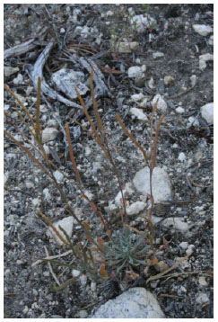

*Arabis fecunda* (Brassicaceae) is a rosette-forming, short-lived perennial endemic to southwest Montana, USA. It occurs on sparsely-vegetated slopes in a mosaic of grasslands or sagebrush steppe at mid- to rather high-elevations. Plants were mapped along 1-meter wide transects and classified to stage annually (Lesica and Shelly 1995).

There are four observable stages: small vegetative class has a single small rosette; the middle-size vegetative class has a single large rosette; the large vegetative class has multiple small- or medium-size rosettes; and the reproductive class, which was collapsed from two classes in the original data. There are no unobservable classes. New recruits may appear in any class including reproductive. All stage transitions were possible. The nature of the seed bank is not known. A seed bank was not included in the model.

Entries in the fecundity matrix were calculated by dividing the number of recruits in a particular stage class by the number of flowering plants the previous year.

Author(s): Peter Lesica, J. Stephen Shelly

Acknowledgements: Pamela M. Kittelson

Funding: Beaverhead National Forest, U.S. Fish and Wildlife Service, The Nature Conservancy

Photo credit: Peter Lesica

*Astragalus scaphoides*

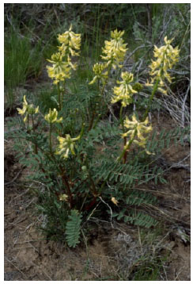

Stage 1 plants were dormant during the growing season. There are four observable stages: Stage 2 (<6 leaves, no stem), Stage 3 (≥6 leaves, no stem), Stage 4 (above-ground stem present) and Stage 5 (reproductive). Nearly all new recruits first appear in Stage 2, but some fall germinants may first appear in the census as Stage 3. Plants alternate between vegetative, flowering and dormant states throughout their lives. Plants may move from any class to any other class. We ignored the potential seedbank following Lesica (1995) but in contrast to Gremer (2010).

Entries in the fecundity matrix were calculated by dividing the number of recruits in a particular stage class by the number of flowering plants in *–*the previous year.

Author(s): Peter Lesica, Elizabeth Crone

Acknowledgements: Joe Elliott, Anne Garde, Lou Hagener, Jennifer Gremer

Funding: Idaho and Montana offices of the Bureau of Land Management, NSF grant s DEB 02–36427, DEB 05-15756

Photo credit: Peter Lesica

*Astragalus tyghensis*

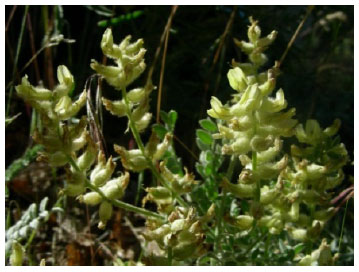

*Astragalus tyghensis* M. Peck (Tygh Valley milkvetch) (Fabacaeae) is an herbaceous, iteroperous perennial. It is a local endemic in north-central Oregon, USA, occurring in oak savanna and sage-brush step in an area with a steep environmental gradient transitioning from moist montane to arid lands. All five populations included in this study are in wild, unmanipulated habitats (Kaye and Pyke 2003). One location, site 41, was grazed heavily prior to approximately 1994, and site 4 had frequent deer herbivory.

In this data set there were seven annual matrices from each population from 1991 to 1998, with a follow-up census in 2008. No seedbank is known in this species, but it is a hard-seeded legume with a strong potential for a persistent seedbank. We recognized five stages for this species based primarily on stem length: seedling, longest stem <10 cm, 10–20 cm, 20–30 cm, and >30 cm. Fecundity was estimated by dividing the seedlings in a given year by the number of reproductive plants in the previous year, and prorating by average reproductive effort (number of flowering stems) of each reproductive stage.

Author(s): Thomas N. Kaye

Acknowledgements:; Ron Halvorson, Matt Carlson, Andrea Thorpe

Funding: USDI Bureau of Land Management, Native Plant Society of Oregon, Oregon Department of Agriculture

Photo credit: Thomas N. Kaye

*Cirsium pitcheri*

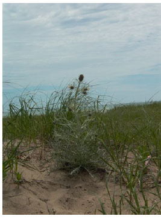

*Cirsium pitcheri* (Asteraceae) is a monocarpic perennial endemic to open sand on North American Great Lakes dunes and beaches. Seed banks appear to be unimportant in this species (Rowland and Maun 2001) and were not incorporated into the models. Seed germination occurs in the spring, flowering occurs after 3 to 8 years with 1–20 flowering heads and averaging 30 flowers per head (McEachern, 1992).

Three Indiana Dunes natural populations (Cipi1, Cipi2, and Cipi3) were mapped and monitored annually beginning in 1988 in circular plots (McEachern 1992; McEachern et al. 1994). A reintroduction (Cipi4) in former habitat at Illinois Beach State Park began in 1991 using annual transplanting of approximately 100 1- or 2-year old plants from 1991 to 2000. Annual demographic mapping and monitoring included all plants in the population, but only individuals naturally recruited from the original transplants were in included in this data set.

For Cipi1, Cipi2, and Cipi3, three stages were defined as follows: seedling (first year plants); juvenile (nonflowering plants older than one year); and adult (flowering plants). For Cipi4, six stages were defined as: seedlings (first year plants); small juveniles (root crown diameter <0.30 cm); medium juveniles (0.30 cm to < 0.70 cm); large juveniles (0.70 cm to < 1.10 cm); pre-flowering (< 1.10 cm); and flowering (Bell et al. 2003). Juvenile stage size categories were determined using the Moloney algorithm (Moloney 1986). Plants < 1.10 cm root crown diameter were classified as pre-flowering plants because this represented the size threshold that most correctly predicted (at 87.4%) flowering the following year.

Entries in the fecundity matrix were calculated by dividing the number of recruits in a particular year by the number of flowering plants the previous year.

Author(s): Tim Bell, Marlin Bowles, Kathryn McEachern

Acknowledgements: We wish to thank Kay Havens, Pati Vitt, Susanne Masi, and Jeremie Fant at the Chicago Botanic Garden, Jenny McBride, Kristin Powell and Michelle Boyle at The Morton Arboretum, and Noel Pavlovic at the USGS Indiana Dunes National Lakeshore and Julie Stumpf at the National Park Service for assistant on restoration and data collection of *Cirsium pitcheri*.

Funding: We also thank the Illinois Endangered Species Board, Illinois Department of Natural Resources, US Fish & Wildlife Service, Indiana Division of Nature Preserves, National Science Foundation, National Fish & Wildlife Foundation and the Indiana Dunes National Lakeshore for funding and permission to conduct research.

Photo credit: Marlin Bowles

*Cypripedium fasciculatum*

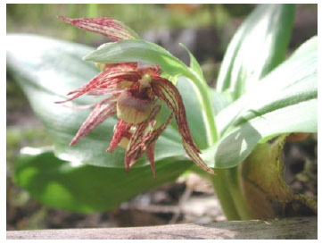

*Cypripedium fasciculatum* (clustered lady’s slipper) (Orchidaceae) is a rare woodland orchid that occurs in coniferous forests in western North America; it is a long-lived iteroparous perennial that can enter dormancy for one or more years. Additionally, seedlings (protocorms) are completely dependent on commensal fungi after germination, and only emerge above ground after 2 or more years. It has been suggested that this species may have a “protocorm bank”, analogous to a seed bank, but the protocorm stage was not modeled due to insufficient information.

This study used data from 28 sites in the Medford District of the Bureau of Land Management in southwestern Oregon, USA, collected 1999–2007 (Thorpe et al. 2007). Study sites were selected based on ownership and protection status (e.g., federal lands under management for conservation value rather than timber production). Sites that experienced fire or management treatments were excluded. Study sites were lumped into 3 environmental regions based on proximity and similarity in elevation, climate, and population trends. Study sites were lumped to improve sample size, as many sites had fewer than 20 individuals. All plants at each site were tagged and censused annually.

Author(s): Amanda Stanley, Andrea Thorpe, Tom Kaye, Penny Latham

Acknowledgements: Mark Mousseaux, Armand Rebiscke, Susan Fritts

Funding: USDI Bureau of Land Management, Native Plant Society of Oregon

Photo credit: Steve Gisler

*Dicerandra frutescens*

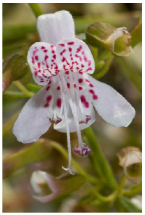

*Dicerandra frutescens* (Lamiaceae) is a short lived (<10 years) iteroparous perennial herb narrowly endemic to Florida scrub on central Florida’s Lake Wales Ridge. Our study taxon has recently been described as *D. frutescens* var. *frutescens*, distinct from another subspecies found further north. *D. frutescens* is a low-growing suffrutescent mint occurring on xeric yellow sands, mainly in inter-shrub gaps (Menges et al. 1999). Fire is a key ecological disturbance in the life history of *D. frutescens*. Fire kills all *D. frutescens* plants, but post-fire recruitment from a persistent soil seed bank is often quite dramatic. Post-fire populations had positive population growth while populations more than six years post-fire were declining.

We have studied 11 *D. frutescens* at Archbold Biological Station continuously since 1988, and here include six unburned populations. We collected data in permanently marked 1 × 1 m square quadrats, selected randomly when densities were high, and subjectively in most populations. At some sites (2, 4, 19), quadrats were arranged into belt transects of 1 m or 2 m widths; at other sites (0, 10, 11) quadrats were scattered along a wider belt transect through the population. Within quadrats, we marked and mapped all plants; recording survival and recruitment data quarterly.

Fecundity data are derived from eleven years of subsampling of the numbers of fruits per flowering branch tip and the number of nutlets (the dispersal unit) per fruit. Germination data from many trials was used to derive a species-wide weighted average for germination percentage. We did not have direct data on how many ungerminated seeds were alive and dormant. We estimated germination from the seed bank and seed bank survival by simulation, matching observed population trajectories to ones simulated with various combinations of three study-wide parameters (seed survival in the seed bank, germination from the seed bank 0–3 years post-fire, and germination from the seed bank more than three years post-fire (for details, see Menges et al. 2006). Finally, we adjusted the transitions from both current year’s fecundity and the seed bank to seedlings by discounting seedling mortality between the time they were first observed and the annual September census. In Menges et al. (2006), these matrices were used in simulations of different fire regimes, using matrix selection with fire as the environmental driver. Bayesian modeling approaches have been applied to this species as well (Evans et al. 2008, 2010).

Author(s): Eric Menges, Pedro Quintana-Ascencio

Acknowledgements: Alaa Craddock, Marcia Rickey, Gretel Clarke, Stacy Smith, Sarah Haller and several cohorts of plant lab interns for field assistance (complete list of interns available at http:www.archbold-station.org/abs/staff/menges/esmcvasst.htm)

Funding: National Science Foundation (DEB 98-15370, DEB 0233899, DEB 0812717), Florida Division of Forestry

Photo credit: Reed Bowman

*Eryngium cuneifolium*

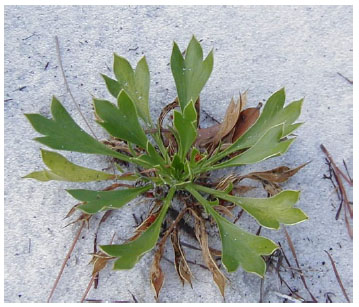

*Eryngium cuneifolium* (Apiaceae) is a U.S. federally endangered, iteroparous, perennial herb. Vegetative plants consist of a ground-hugging rosette, but reproductive plants produce many heads of flowers in the fall. It is narrowly endemic to the southern portion of the Lake Wales Ridge, central Florida, USA and is a habitat specialist on Florida rosemary scrub. *E. cuneifolium* plants are killed by fire but the populations often recover rapidly post-fire from a persistent soil seed bank, which probably can last for six years or more.

We studied *E. cuneifolium* at one of its few protected sites, at Archbold Biological Station (Florida). We have studied 12 populations but included six long-unburned populations for this project. Populations were studied since 1988 but here we include data beginning in 1990. We conduct complete censuses of individuals in the study areas, tracking survival, plant size, and a fecundity metric (number of heads).

We defined six life-history stages by combining morphologically defined stages (e.g., vegetative vs. reproductive plants) with divisions based on size (rosette diameter). The six stages were: persistent seed bank, yearlings (new plants < 3 cm), vegetative plants, and three sizes of flowering plants: small (rosette diameter <6 cm), medium (6.1–10.5 cm), and large (>10.5 cm); separated using the Moloney (1986) algorithm. We used the products of number of flowering stems, heads per stem, seeds per head, seed germination, and seed and seedling survival until the annual census (i.e., to yearlings) to calculate six fertility values, (3 reproductive stages, transitions to yearlings or into the seed bank). We had limited data for germination and seed bank rates, but were able to iteratively select values based on predicting population trajectories (see Menges and Quintana-Ascencio 2004 for details). The non-reproductive part of each matrix was directly derived from annual census data, except when a stage had n < 6, when we pooled data from similar populations, time-since-fire, and years.

Author(s): Eric Menges, Pedro Quintana-Ascencio

Acknowledgements: Alaa Craddock, Marcia Rickey, Gretel Clarke, Stacy Smith, Sarah Haller, and several cohorts of plant lab interns for field assistance (complete list of interns available at http:www.archbold-station.org/abs/staff/menges/esmcvasst.htm)

Funding: National Science Foundation (DEB 98-15370, DEB 0233899, DEB 0812717), Florida Division of Forestry

Photo credit: Eric Menges

*Gentiana pneumonanthe*

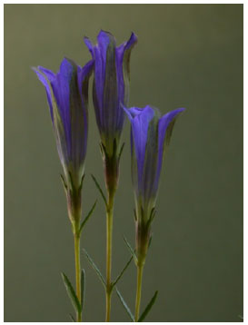

*Gentiana pneumonanthe* L. (Gentianaceae) is an iteroparous perennial herb that occurs in heathlands and hay meadows on nutrient-poor, wet soils from S-Scandinavia to N-Spain and Portugal, and from the United Kingdom into Siberia. Adult reproductive plants have 1–10 flowering stalks, each bearing 1–6 flowers. Dust seeds are <1 mm and produced in dehiscent fruits, with 350–1000 seeds per fruit depending on soil nutrient status. Germination generally occurs in spring. Sowing experiments and soil core studies did not support the existence of a persistent seed bank (Oostermeijer et al. 1996).

In consultation with reserve managers, we selected four heathland and two hay meadow populations that differed in management and successional stage (Oostermeijer et al. 1996). For each population, fate of individual plants was recorded by mapping and relocating them annually. Mapping occurred on the basis of co-ordinates in a 1 × 1m<sup>2</sup> frame, with 0.1 × 0.1 m<sup>2</sup> subdivisions.

In heathlands, disturbance occurred in the form of sod-cutting, which completely sets back vegetation succession because it removes all vegetation and a large part (top 10–15 cm) of the organic layer. This management practice is characteristic of the former small-scale agricultural land use that over the course of centuries has resulted in the formation of the semi-natural heathland landscape. The cut sods were transported to sheep pens (‘pot stables’) near the local villages, where they were mixed with sheep dung during the vegetation season. The resulting mixture was used to fertilize the arable fields. The pot stable agriculture ceased to exist after artificial fertilizers were developed, leading to the demise of many heathlands and its characteristic biodiversity. Currently, heathlands only remain in nature reserves, which are managed according to the ancient sod-cutting and sheep herding practices described above.

The hay meadows were located on more nutrient-rich soils created by nearby brooks and rivers. Disturbance here consisted of annual mowing with subsequent haymaking, currently performed by conservation managers to maintain the species-rich grasslands. The annual mowing slows down or even halts succession, so that the vegetation structure doesn’t change very much over time. Hence, in comparison with sod-cut heathlands, the disturbance of hay meadows is of a much lower intensity.

Author(s): Gerard Oostermeijer, Hans den Nijs, Sheila Luijten, Albertine Ellis-Adam

Acknowledgements: Edwin de Boer helped with much of the field work in 1994 and 1995 and Marc Brugman helped construct and analyze the first matrix models.

Photo credit: Gerard Oostermeijer

*Haplopappus radiatus*

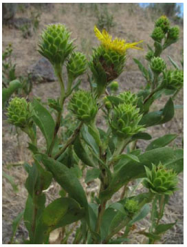

Four stages were recognized for the matrix models, seedlings (defined as first year plants), small vegetative (<5 leaves), large vegetative (>4 leaves), and reproductive. This species does not appear to maintain a persistent soil seed bank based on sieved soil samples (*unpublished data*).

Author(s): Thomas N. Kaye

Acknowledgements: Robert J. Meinke, Jean Findley

Funding: USDI Bureau of Land Management, Native Plant Society of Oregon, Oregon Department of Agriculture

Photo credit: Thomas N. Kaye

*Horkelia congesta*

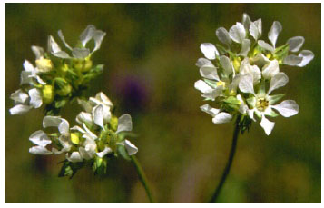

*Horkelia congesta* ssp. congesta (Shaggy horkelia) (Rosaceae) is an herbaceous perennial that reproduces by seed and occurs in grassland and oak savanna remnants in the Willamette Valley and on grassy balds in the Umpqua Valley, Oregon (USA). The subspecies congesta is endemic to Oregon. Plants form rosettes of basal leaves and eventually produce one or more flowering stems. No studies have documented the breeding system of the species, but our field observations indicate that insects (solitary bees and syrphid flies) are responsible for cross-pollination.

Sampling for *Horkelia* on land managed by the US Bureau of Land Management was initiated in 1993 at the Long Tom Area of Critical Environmental Concern (ACEC) (Kaye and Benfield 2004). In this data set there were six annual matrices from 1993 to 1999, with a follow-up census in 2009. We recognized six possible stages based on both life history and plant size: seedling; vegetative plants with rosette diameter 12 cm or less; vegetative plants with rosette diameter 13 cm or greater; reproductive plants with one flowering stem; reproductive plants with two stems; and reproductive plants with three or more stems. Fecundity was estimated by dividing the number of seedlings in a given year by the number of reproductive plants in the previous year, and prorating by average reproductive effort (number of flowering stems) of each reproductive stage. No persistent seedbank is known for this species and no seedbank was included in the matrix model.

Author(s): Thomas N. Kaye

Acknowledgements: Nancy Sawtelle

Funding: USDI Bureau of Land Management, Native Plant Society of Oregon, Oregon Department of Agriculture

Photo credit: Thomas N. Kaye

*Hypericum cumulicola*

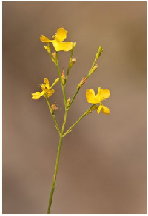

*Hypericum cumulicola* (Small) W. P. Adams, Highlands scrub Hypericum (Hypericaceae), is an endangered, short-lived, iteroparous, perennial herbaceous species, endemic to the southern portion of the Lake Wales Ridge, central Florida, USA. It is almost entirely limited to open sand areas in the xeric Florida rosemary scrub.

This study includes six populations in patches of long unburned scrub, which were sampled in a stratified random fashion along 1-m-wide belt transects (to include at least 70 individuals) We defined six life-history stages by combining morphologically defined stages (e.g., vegetative vs. reproductive plants) with divisions based on size (using the Moloney algorithm): (1) seeds in the seed bank; (2) first-year plants (seedlings); (3) vegetative stage; (4) small flowering individuals, 12–33 cm tall; (5) medium flowering individuals, 34–50 cm, and (6) large flowering individuals, > 50 cm. Fertility terms in the model represent newly recruited individuals surviving until August or individual contributions to the seed bank. We estimated seedling recruitment from permanent quadrats and partitioned seedling numbers among reproductive stages in proportion to stage-specific abundance and seed production. We estimated stage-specific contributions to dormant seed bank by multiplying the number of ungerminated seeds by their probability of remaining in the seed bank. We always assumed recruitment from seed bank, even when there was no evidence of recruitment in permanent quadrats in a given year. Seedling production from the seed bank was estimated on the basis of experimental observed seed survival and germination, seedling survival in the field until August, and annual variation in recruitment. More detailed information can be found in Quintana-Ascencio et al. 1998, 2000, and 2003.

Author(s): Pedro Quintana-Ascencio, Eric Menges

Acknowledgements: Alaa Craddock, Marcia Rickey, Gretel Clarke, Stacy Smith, Sarah Haller, and several cohorts of plant lab interns for field assistance (complete list of interns available at http:www.archbold-station.org/abs/staff/menges/esmcvasst.htm). M. Evans, M. Martínez Icó, M. Morales-Hernández, Rick Lavoy, A. Z. Quintana-Morales, E. M. Quintana-Morales, and Carl Weekley have contributed significantly to this work.

Funding: This work was supported by Fulbright and Consejo Nacional de Ciencia y Tecnología (Mexican Government) through a fellowship (46610); El Colegio de la Frontera Sur, San Cristóbal de Las Casas, Chiapas, Mexico; Fish and Wildlife Service, Archbold Biological Station; the State University of New York at Stony Brook, the National Science Foundation (DEB98-15370, DEB-0233899, DEB-0812717, DEB-0812753), the Florida Division of Forestry’s Plant Conservation Program; and the Center for Plant Conservation.

Photo credit: Reed Bowman

*Lathyrus vernus*

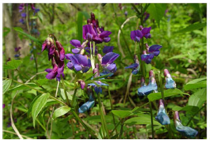

*Lathyrus vernus* is a long-lived forest understory herb distributed from central and northern Europe to east of the Ural Mountains. *Lathyrus vernus* lacks specialized organs for vegetative spread. One to several erect shoots sprouts from a subterranean rhizome early in spring. It usually bears 5–30 purple-red flowers. Seeds produced in one season may survive for up to at least five years in the soil seed bank. Recruitment to populations is seed limited; increased densities after seed addition experiments persist for 10 years. Individuals sometimes remain dormant, without above-ground parts, for one or more seasons. Growth of established plants is slow and plants often do not reach the threshold size for reproduction until after 10–20 years. Several types of interactions with animals have important effects on the performance of individuals.

The data for this study were collected in 10 populations in southeastern Sweden during 1988–1991 and in 2009. One permanent plot per population was established. The borders of permanent plots usually coincided with the border of *L. vernus* patches and plots included a major proportion of the individuals within the (sub-) populations. Distances between patches were considerably larger than seed dispersal distances. The number of individuals recorded within permanent plots can thus be regarded as an estimate of population size. Data to parameterize the transition matrix models were collected from all individuals in permanent plots. Individuals were assigned to one of seven stages: (1) seeds, in the seed bank; (2) seedlings; (3) very small, established individuals in the seedling size range (estimated aboveground volume of 2–24 mm<sup>3</sup>); (4) small, individuals larger than seedlings but smaller than the minimum size at which reproduction occurs (25–230 mm<sup>3</sup>); (5) intermediate (231–772 mm<sup>3</sup>); (6) large (773–mm<sup>3</sup>); (7) dormant, rhizomes lacking above-ground tissue. Because a few population × year × stage combinations had no observations, we substituted these missing values by the means of the other study years. The numbers of intact and damaged seeds were counted in marked individuals but seed survival, germination rates and seedling survival were estimated from the seed sowing experiments. Probabilities estimated in sowing experiments agreed closely to estimates based on the emergence and survival of seedlings recorded in demographic plots.

Author(s): Johan Ehrlén

Acknowledgements: Hannah Östergård

Funding: The Swedish Research Council

Photo credit: Katarina Fast Ehrlén

*Liatris scariosa*

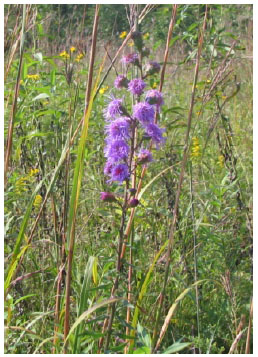

Savanna Blazing Star (*Liatris scariosa* (L.) Willd. var. nieuwlandii Lunell, Asteraceae) is an herbaceous perennial listed as threatened in Illinois, USA due to its rarity and loss of temperate oak savanna habitats (Bowles et al. 1988; Herkert and Ebinger 2002). The species typically occurs in savanna or open disturbed habitat without tallgrass cover (Bowles et al. 1988)

The study population occurs within the Hickory Creek Barrens Nature Preserve, located on the north side of Hickory Creek, Will County, Illinois, USA. We monitored Liatris demography annually using 80 1-m × 0.5-m permanent plots along four 50-m transects (Bell and Bowles 2003). A pair of randomly located parallel transects were placed in a site dominated by *Danthonia spicata* and another pair of parallel transects were randomly located in a site dominated by the introduced *Andropogon gerardii* (which is known to influence *Liatris* demography, see Bell et al. 1999). Stages were defined as: seedling (first year plants); juvenile (nonflowering plants older than one year); adult (flowering); vegetative (previously flowered, but not currently flowering); and dormant (not found in current year but alive in subsequent year(s)). Seeds banks appear to be unimportant in this species and were not incorporated into the models. Entries in the fecundity matrix were calculated by dividing the number of recruits in a particular year by the number of flowering plants the previous year.

In 1995, 2000, and 2010 we estimated cover of *A. gerardii* for each plot by counting the number of square decimeters (out of 50) in which each of these are found. Plots were categorized as containing no *A. gerardii* (Lisc0, 34 plots), 1–50% *A. gerardii* cover (Lisc1, 25 plots) or 51–100% *A. gerardii* cover (Lisc2, 21 plots). The models were developed separately for each of these *A. gerardii* cover categories.

Author(s): Tim Bell, Marlin Bowles

Acknowledgements: Nathan Schroeder, Maria Boyle, Michelle Boyle, Don Nelson, Espy Nelson, and the Forest Preserve District of Will County assisted on data collection of *Liatris scariosa*.

Funding: We also thank the Forest Preserve District of Will County and the Illinois Nature Preserves Commission for funding and permission to conduct research.

Photo credit: Tim Bell

*Lomatium cookii*

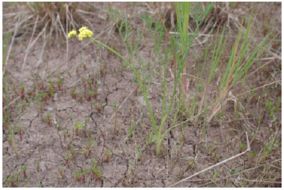

*Lomatium cookii* J.S. Kagan (Cook’s lomatium) (Apiaceae) is listed as endangered by the State of Oregon and by the U.S. Fish and Wildlife Service. Plants are usually less than 3 dm tall and inconspicuous except when in flower. Flowering stems begin to emerge from a rosette of leaves in late February and flowers usually bloom around mid-March and continue into May. Fruits are flat and oblong and mature in June and July. Lomatium cookii is endemic to southwestern Oregon. Two population centers are known, the Illinois Valley in Josephine County and the Agate Desert north of the Medford Plains in Jackson County. Data for the matrix models included here are from two populations in the Illinois Valley at the French Flat Area of Critical Environmental concern (Kaye and Pyke 2003). The populations of *L. cookii* studied in the Illinois Valley are found in moist, grassy serpentine meadows dominated by Danthonia californica. Both were wild, unmanipulated populations. In this data set there were five annual matrices from each population from 1994 to 1999, with a follow-up census in 2009.

We recognized six stages for this species based on size and reproduction: seedling (first year with cotyledons), vegetative plant with 1–2 leaves, vegetative plant with 3 or more leaves, reproductive plant with 1 umbel, reproductive plant with 2 umbels, and reproductive plants with 3 umbels. Plants with 1 umbel typically have only male flowers and produce no fruits. Fecundity was estimated by dividing the seedlings in a given year by the number of reproductive plants in the previous year, and prorating by average reproductive effort (number of flowering stems) of each reproductive stage (except 1 umbel plants). The species does not maintain a significant persistent soil seedbank, and no seedbank stage was included in the matrix model.

Author(s): Thomas N. Kaye

Acknowledgements: Joan Seevers, Mark Mousseaux

Funding: USDI BLM, Native Plant Society of Oregon, Oregon Department of Agriculture

Photo credit: Thomas N. Kaye

*Neobuxbaumia macrocephala*

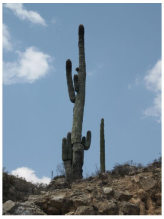

*Neobuxbaumia macrocephala* (Cactaceae) is a long-lived branching columnar cactus that may reach ca. 15 m in height. It is endemic to the Tehuacan Valley region, in central Mexico, where it occupies semi-desert areas and forms sparse populations. Branch tips are characterized by the presence of a reddish pseudo-cephalium from which purple flowers emerge in late spring; they are bat pollinated and produce purple fruits that ripen in the summer. Seeds are shed during the summer months (July–August), coinciding with the rainy season; they do not possess any dormancy, thus they may germinate readily given enough soil humidity. Therefore, it is unlikely that they remain in the soil for more than a few months.

Plants (ca. 360) were mapped and followed for five years in seven 20 × 200 m plots. Ten size categories were defined according to plant total length (see Esparza-Olguin et al. 2005 for details). Fecundity entries were calculated by multiplying the mean number of seeds produced per individual by the probability of seed germination obtained from seed germination experiments in natural conditions. The probabilities of seedling survival were also obtained from field experiments as naturally established seedlings were found to be in very low numbers. For details on the methods, the study site and the species see Esparza-Olguin et al. (2002) and Esparza-Olguin et al. (2005).

Author(s): Teresa Valverde

Acknowledgements: Ligia G. Esparza-Olguín, Elena Vilchis-Anaya, Maria C. Mandujano

Funding: CONABIO R129 and CONACyT

Photo credit: Teresa Valverde

*Phyllanthus emblica* (left) and *Phyllanthus indofischeri* (right)

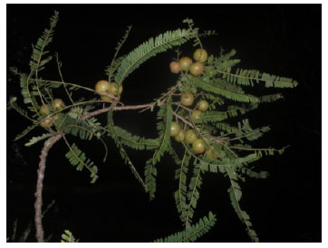

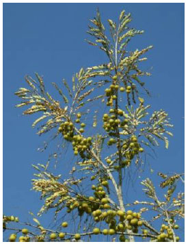

*Phyllanthus emblica* and *P. indofischeri* are small trees that grow up to 10–15 m in height, respectively. *P. emblica* is distributed throughout the dry deciduous forests of south and southeast Asia, and *P. indofischeri* is endemic to scrub forests of the Deccan region of South India. Fruits of both species have fleshy exocarps that mature from December to February. The stony endocarp dehisces and the seeds are mechanically dispersed. Ungulates eat the fleshy fruit and regurgitate the endocarps containing the seeds. Germination occurs from May–August.

In December 1999, 7 10x100 m permanent plots were established to monitor *P. emblica* and 10 for *P. indofischeri*, in the Biligiri Rangaswamy Temple Wildlife Sanctuary, Karnataka, India. All individuals of the study species in each plot were tagged and measured. The number of fruit per tree was counted on a set of trees inside and outside the transects (N = 163 P. emblica and N = 176 P. indofischeri), each November, before the fruits mature. All plots were recensused annually for ten years (1999–2009).

Individuals were classified into seven stages based on basal area and life-history: seeds in the seedbank; new seedlings (<1 yr old); seedlings ≤ 0.072 cm<sup>2</sup>; small juveniles 0.072< x ≤0.787 cm<sup>2</sup>; large juveniles 0.787 < x ≤19.643 cm<sup>2</sup>; small adults (reproductive in *P. indofischeri* only) 19.643 < x ≤63.643 cm<sup>2</sup>; large adults (reproductive in both species) >63.643 cm<sup>2</sup>. Basal area was used as a measure of size since some individuals had multiple stems. When there was no movement from one transition to another in a given year we used the mean value across years. For *P. emblica*, the number of small adults was very low across all transects so we estimated transition rates from 31 individuals in experiments outside of the transects.

Fecundity values were calculated from the proportion of trees fruiting in a given year, the mean number of fruit/fruiting tree, the mean number of seeds/fruit, the proportion of fruit harvested by people, the proportion of fruit removed by frugivores, the proportion of seeds germinating in the field, the proportion of seedlings surviving from germination to the census time, and the proportion of seeds that survive in the soil seedbank until the next census. Seed germination, seedling survival, survival of seeds in the seedbank and the proportion of fruit removed by frugivores were estimated from field and nursery experiments. Calculations did not include germination of seeds regurgitated by frugivores since seed germination trials from three separate years revealed no or very low rates of germination of regurgitated seeds and high seed predation. The fecundity calculations produced estimates of the number of new seedlings per year close to what was observed in the field at each census. The proportion of seeds staying in the seedbank was constant in all matrices and estimated from a 2 year seedbank experiment.

Author(s): Tamara Ticktin, Rengaian Ganesan

Acknowledgements: Siddappa Setty, Mallegowda Paramesha

Funding: NSF grant OISE03-52827 to TT, and Ford Foundation and Dorabji Tata Trust to ATREE

Photo credits: R. Ganesan

*Silene acaulis*

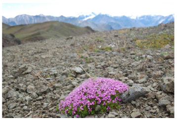

*Silene acaulis* is a long-lived perennial herbaceous cushion plant inhabiting arctic and alpine tundra throughout the pan-boreal zone. Plants have a taproot and are non-clonal, so individuals are easily distinguished. Once they are reproductively mature, plants produce copious flowers soon after snowmelt. The species is gynodioecious; hermaphrodites produce fewer seeds than females. Flowers pollinated by bumblebees produce dry capsules that dehisce in late summer to release seeds that have no appendages to enhance dispersal. Germination begins the following spring, but there is a short-lived (2–3 year) seed bank.

The study populations were established in 1995 in the Wrangell-Saint Elias National Park, near the town of Kennecott, Alaska, USA (see Morris and Doak 2005 for details). All plants encountered along permanent transects haphazardly located where plants were common were marked, measured, and censused once per year in subsequent years (as of 2011, two of these populations, PA and RI, are still being followed).

Seed survival/germination and seedling survival were estimated by adding known numbers of seeds to field plots in two of the populations and censusing them for seedlings in subsequent years, subtracting the number of seedlings in adjacent control plots to account for background germination (see Morris and Doak 2005 for details). Projection matrices were constructed by dividing plants into 12 stages as follows: (1) seeds in seed bank, (2) seedlings, (3)1 branch, older than seedling, (4) 2–5 branches, (5) 6–10 branches, (6)11–19 branches, (7) >19 branches, cushion area ≤12.5 cm<sup>2</sup>, (8) >19 branches, cushion area >12.5 and ≤25 cm<sup>2</sup>, (9) >19 branches, cushion area >25 and ≤50 cm<sup>2</sup>, (10) >19 branches, cushion area >50 and ≤100 cm<sup>2</sup>, (11) >19 branches, cushion area >100 and ≤200 cm<sup>2</sup>, and (12) >19 branches, cushion area >200 cm<sup>2</sup>.

Because the seed bank and seedling stages were not estimated using data from the transects in each population, they are treated as nobserved stages. Both growth to larger stages and reversion to smaller stages were frequently observed. The matrices assume a post-breeding census. The input to the seed bank for each reproductive stage (stages 7–12) is the product of: the mean number of fruits produced by an individual in that stage in a year, the average number of seeds per fruit; one year survival of seeds in the soil, and the probability that a seed does not germinate in a year. The input to the seedling class for each reproductive stage is the product of: the mean number of fruits produced by an individual in that stage in a year, the average number of seeds per fruit; over-winter survival of seeds in the soil, the probability that a seed germinates in a year, and the survival of seedlings for one summer. Seed and seedling survival, the germination rate, and seeds per fruit were treated as constant, but other vital rates (survival of plants larger than seedlings, size transition, and fruit production) differed among years.

Author(s): William F. Morris, Daniel F. Doak

Acknowledgements: We thank the many field assistants who have helped us to monitor our study populations over many years.  
Funding: We gratefully acknowledge financial support from United States National Science Foundation grants DEB-9806818, DEB-0087096, and DEB-0716433.

Photo credit: Tracy S. Feldman

*Silene spaldingii*

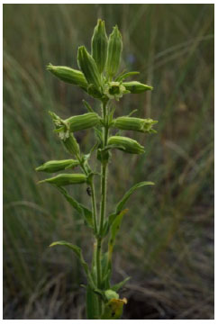

*Silene spaldingii* occurs in semi-arid grasslands from southeast British Columbia to west-central Idaho and adjacent Oregon. It bears 3–20 flowers borne in a branched, terminal inflorescence. Some germination may occur in fall as well as in spring. Prolonged dormancy (plants do not appear during one or more growing seasons) of established plants is common, with bouts of dormancy usually lasting 1 to 2 years (Lesica 1999*b,a*, Lesica and Crone 2007). Plants were mapped along 1-meter wide transects and classified to stage annually.

There are three observable stages: rosette, vegetative, and reproductive; and one unobservable stage, prolonged dormancy. A plant’s flowering stage is larger than its vegetative stage which is larger than the rosette. All rosettes are new recruits, but fall germinants may first appear in the census as vegetative stems. Rosettes transitioned only to the rosette or dormant stages. Otherwise plants alternate between vegetative, flowering and dormant states throughout their lives. Plants may move from any class to any other class except vegetative, and reproductive plants never regress to rosettes. Seeds lack a hardened coat, so a long-term seed bank is unlikely; a seed bank was not included in the model. Entries in the fecundity matrix were calculated by dividing the number of recruits in a particular stage class by the number of flowering plants for each year (Lesica 1999*a*, Lesica and Crone 2007).

Author(s): Peter Lesica, Elizabeth Crone

Acknowledgements: Hall, Shannon Kimball, Pamela Kittelson, Maria Mantas

Funding: The Nature Conservancy, NSF grant DEB 02–36427, U.S. Fish and Wildlife Service

Photo credit: Peter Lesica

*Trillium grandiflorum*

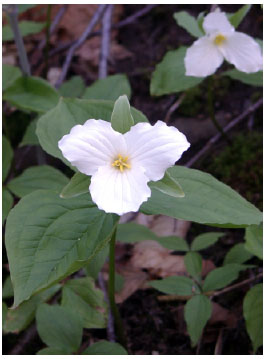

*Trillium grandiflorum* (Melanthiaceae) is an herbaceous, iteroperous perennial. It has a broad distribution in eastern North America, and is typically found in deciduous and mixed upland forests. In Pennsylvania, flowering occurs in late April and early May, and plants die back to just below ground level in the summer. Seeds are double dormant, requiring two years to complete germination. I followed seeds in the field and found no evidence for seeds living longer than two years.

I studied *Trillium grandiflorum* in 12 populations. Populations were located in deciduous forests in northwestern Pennsylvania and were separated by 4 km to 55 km.; While populations differed in a variety of abiotic and biotic factors, browsing by white-tailed deer had dramatic demographic consequences and was explicitly modeled. In each population, individuals were followed in 5 and 27 1-m<sup>2</sup> plots, located along a single transect.

Six life stages were recognized: germinants, seedlings, 1-leaf, small 3-leaf, large 3-leaf and reproductive. Germinants are first year individuals with a radicle present. Germination probability was quantified by planting a known number of seeds in a seed basket at all sites and then destructively sampling these baskets after a year. Seedlings are second year individuals with a single cotyledon. These individuals were sampled by planting a known number of seeds in a seed basket at all sites and then counting the number of seedlings present after two years. The proportion of plants that transition from the germinate to seedling stage class is calculated as the proportion of seeds surviving to the seedling stage class divided by the germination probability. If seedlings survive, they produce a single true leaf in the next year. Plants can stay in this 1-leaf stage class for one or more years. Plants in the small 3-leaf stage class contain a whorl of three leaves and the length of any one leaf is less than 5 cm. Large 3-leaf plants have leaf lengths greater than or equal to 5 cm. Reproductive plants contain a whorl of three leaves and a single flower. 3-leaf and reproductive staged plants can remain dormant below ground for one or more growing seasons. However, dormancy was rare, and therefore dormant individuals were classified as large 3-leaf plants. More detailed information can be found in Knight (2003, 2004) and Knight et al. (2009).

Author(s): Tiffany M. Knight

Acknowledgements: Susan Kalisz

Funding: National Science Foundation (DEB-0105000 and DEB-0108208), McKinley and Darbaker Research Funds and Botany in Action (Phipps Conservatory and Botanical Garden)

Photo credit: Tiffany M. Knight

**CLASS III.** **DATA SET STATUS AND ACCESSIBILITY**

**A. Status**

Latest update: April 2011 for all data files.

Latest Archive date: April 2011

Metadata status: Metadata are complete to last update and are stored with data.

**B. Accessibility**

Storage location and medium: All data are stored in digital form by individual authors and in multiple back-ups. The database is also available via the National Center for Ecological Analysis and Synthesis and Knowledge Network for Biocomplexity (KNB).

**Contact person:**

Contact persons:

- M. Ellis, email: martha.ellis@umontana.edu, tel: 406-542-4155, Wildlife Biology Program, University of Montana, Missoula, MT 59812.
- J. Williams, email: jwilliams@nceas.ucsb.edu, tel: 805-882-9218, National Center for Ecological Analysis and Synthesis, 735 State Street Suite 300, Santa Barbara, CA

**Copyright restrictions:** None.

**Proprietary restrictions:** None. Users interested in the underlying individual-fate data for particular species of interest are asked to please contact the data contributor (see Species_Information.txt).

**Costs:** None.

**CLASS IV.** **DATA STRUCTURAL DESCRIPTORS**

**A. Data Set File**

**Identity:**

Species_Information.txt -- Species data for all studies, including study details, limited life history characteristics, and species descriptions.

Population_data.txt -- Details on population locations, habitats, and observed population status at study end and revisit.

Transition_Matrices.txt -- Annual transition matrices and observed stage structures for each population and year of study.

**Size:**

Species_Information.txt – 20 lines (not including header row), 5 KB

Population_data.txt – 82 lines (not including header row) , 8 KB

Transition_Matrices.txt – 461 lines (not including header row) , 249 KB

**Format and storage mode:**

ASCII text, tab delimited.

Special characters/fields:

1. All missing values are denoted as “NA”
2. Matrices and vectors are stored as strings using MATLAB syntax, with square brackets enclosing matrix elements, spaces between elements, and rows separated by semi-colons (e.g. [A B ; C D] represents a 2 × 2 matrix with A as the element in the 1st column of the 1st row, B in the 2nd column of the 1st row, C in the 1st column of the 2nd row, and D in the 2nd column of the 2nd row). Code for reading these strings using the R statistical language is provided below:

#R function for reading in MATLAB matrix/vector

convert_mx <- function(mx_str){

> mx_str<-substr(mx_str, 2, nchar(mx_str)-1)

> mx_str<-gsub(‘; ‘,’;’,mx_str)

> mx_str<-gsub(';', ',', mx_str)

> mx_str<-gsub(' ', ',', mx_str)

> mx_str<-paste('c(',mx_str,')',sep='')

> mx <- eval(parse(text=mx_str))

> mx<-matrix(mx, nrow=sqrt(length(mx)), byrow=T)

> return(mx) }

#Example

> mx_str = "[1 2; 3 4]"

> mx = convert_mx(mx_str)

> mx

[,1] [,2]

[1,] 1 2

[2,] 3 4

**B. Variable definitions**

Species_Information.txt

[output not shown]

Population_data.txt

| Variable name | Variable definition | Units | Storage type | Range numeric values | Missing value codes |
| --- | --- | --- | --- | --- | --- |
| SPP | 4 letter species code (refer to species table for species names) | text | string | N/A | N/A |
| POP | Population code | text | string | N/A | N/A |
| Lat | Latitude | decimal degrees | double | 18.25 – 61.49 | ‘NA’ |
| Long | Longitude | decimal degrees | double | -142.85 to 81.36 | ‘NA’ |
| Treatment | Whether or not an experimental treatment was used | text | string | N/A | ‘NA’ |
| No. Matrices | Number of matrices used | number | integer | 2 to 12 | N/A |
| StartYr | Start year of data collection | year | integer | 1987 to 1999 | N/A |
| EndYr | End year of data collection | year | integer | 1991 to 2004 | N/A |
| TestYr | Year when population was re-sampled to count the number of individuals in each stage | year | integer | 2007 to 2010 | N/A |
| N_EndYr | Vector of stage structure of a population during the final year | vector | string | N/A | ‘NA’ |
| N_TestYr | Vector of stage structure of a population during the test year | vector | string | N/A | ‘NA’ |

Transition_Matrices.txt

| Variable name | Variable definition | Units | Storage type | Range numeric values | Missing value codes |
| --- | --- | --- | --- | --- | --- |
| SPP | 4 letter species code | Text | String | N/A | N/A |
| POP | Population code | Text | String | N/A | N/A |
| YR | Initial year for transition (i.e., a transition matrix for 1998-1999 is listed as 1998). | Year | integer | 1988–2003 | N/A |
| Mx | Annual transition matrix | Matrix | String | Probabilities & recruitment, all values >=0. | N/A |
| Tmx | Annual transition matrix including only transition probabilities (no fecundity). | Matrix | String | Probabilities [0,1] | N/A |
| Nx | Vector of observed stage structures (counts of individuals in each stage) | Vector | String | 0 - __ | “NA” indicate unobserved stages. |

**CLASS V.** **SUPPLEMENTAL DESCRIPTORS**

**A. Data acquisition**

Matrices and population vectors in Transition_Matrices.txt and Population_data.txt were built from demographic data collected on individually marked plants from each study. Population vectors contain counts of the number of individuals in each life stage in each year. Transition rates (survival and growth/transition between stages) were calculated directly from observed individual fates, using both our own code and functions from the ‘popbio’ package in R (Stubben and Milligan 2007). In a few circumstances due to small sample sizes or cryptic stages, not all transitions could be observed directly from individual data. In these cases, sample sizes were pooled across years or estimated from other data sources and then added into the survival matrices independently. Methods for estimating fecundity parameters varied by study. These methods can be found in subproject descriptions (Class II, Section B) and in original citations. The full annual transition matrices (mx) are the sum of survival matrices (Tmx) and fecundity matrices. Stages are generally ordered by size or age, with regression to lower stages possible for many species.

**B. Quality assurance/quality control procedures**

These data have been subjected to a multiple step review process. Individual fate data from each original subproject were subject to the author’s own review protocols. Prior to matrix construction, fate data were error checked for impossible or unlikely transitions. Matrices were checked against previously published models. Stage vectors were compared to original data files. All other data were checked visually by contacts listed in Species_Information.txt and tested for internal consistency by M. Ellis and J. Williams.

**C. Related material:** n/a.

**D. Computer programs and data processing algorithms:** see Special Characters/Fields, Class IV, Section A.

**E. Archiving:** n/a

**F. Publications and results:**

Analyses of these data have contributed to the following manuscripts:

Crone et al., *unpublished*

**G. Publications using the same sites:**

| **Species** | **Publications** |
| --- | --- |
| *Arabis fecunda* | (Lesica and Shelly 1995) |
| *Astragalus scaphoides* | (Lesica 1995, Crone and Lesica 2004, Crone et al. 2005, Gremer 2010) |
| *Astragalus tyghensis* | (Kaye and Pyke 2003) |
| *Cirsium pitcheri* | (McEachern 1992, McEachern et al. 1994, Rowland and Maun 2001, Bell et al. 2003) |
| *Cypripedium fasciculatum* | (Thorpe et al. 2007) |
| *Dicerandra frutescens* | (Menges et al. 1999, Menges et al. 2006, Evans et al. 2008, Menges 2008, Evans et al. 2010) |
| *Eryngium cuneifolium* | (Menges and Kimmich 1996, Menges and Quintana-Ascencio 2004) |
| *Gentiana pneumonanthe* | (Oostermeijer et al. 1996, Oostermeijer 2000) |
| *Haplopappus radiatus* | (Kaye and Pyke 2003) |
| *Horkelia congesta* | (Kaye and Benfield 2004) |
| *Hypericum cumulicola* | (Quintana-Ascencio et al. 1998, Quintana-Ascencio and Menges 2000, Pico et al. 2003, Quintana-Ascencio et al. 2003) |
| *Lathyrus vernus* | (Ehrlen 1995*b, a*) |
| *Liatris scariosa* | (Bowles et al. 1998, Bell et al. 1999, Bell et al. 2000, Herkert and Ebinger 2002, Bell and Bowles 2003) |
| *Lomatium cookii* | (Kaye and Pyke 2003) |
| *Neobuxbaumia macrocephala* | (Esparza-Olguín et al. 2002, Esparza-Olguín et al. 2005, Valverde and Esparza-Olguín 2009) |
| *Silene acaulis* | (Morris and Doak 1998, 2004, 2005, Morris et al. 2008, Doak and Morris 2010) |
| *Silene spaldingii* | (Lesica 1997, 1999*a, b*, Lesica and Crone 2007) |
| *Trillium grandiflorum* | (Knight 2003, Knight 2004, Knight 2007, Knight et al. 2008, Knight et al. 2009) |

**H. History of data set usage**

Data set update history: Data files were compiled in current form in 2011.

Review history: n/a

Questions and comments from secondary users: n/a

**ACKNOWLEDGMENTS**

**LITERATURE CITED**

Abrams, M. D. 2005. Prescribing Fire in Eastern Oak Forests: Is Time Running Out? Northern Journal of Applied Forestry 22:190–196.

Angert, A. L. 2006. Demography of central and marginal populations of monkeyflowers (Mimulus cardinalis and M. lewisii). Ecology 87:2014–2025.

Bell, T. J., and M. Bowles. 2003. Effect of Big Bluestem cover on Savanna Blazing Star population growth at Hickory Creek Barrens. A report to the Forest Preserve District of Will County.

Bell, T. J., M. Bowles, and R. Hyerczyk. 1999. Does management for tallgrass prairie inhibit Savanna Blazing Star persistence? A report to the Illinois Nature Preserves Commision and the Forest Preseve District of Will County.

Bell, T. J., M. Bowles, and J. McBride. 2000. Factors affecting Savanna Blazing Star persistence: demographic analysis of the Hickory Creek Barrens populations. A report to the Illinois Nature Preserces Commission and the Forest Preserve District of Will County, July 2000.

Bell, T. J., M. Bowles, and K. McEachern. 2003. Projecting the success of plant population restoration with viability analysis. *In* C. A. Brigham and M. M. Schwartz, editors. Population Viability in Plants. Springer-Verlag, Heidelberg, Germany.

Bowles, M., G. Wilhelm, and S. Packard. 1998. The Illinois status of Liastris scariosa (L.) Willd var. nieuwlandii Lunell, a new threated species for Illinois. Erigenia 10:1–26.

Buckley, Y. M., S. Ramula, S. P. Blomberg, J. H. Burns, E. E. Crone, J. Ehrlén, T. M. Knight, J.-B. Pichancourt, H. Quested, and G. M. Wardle. 2010. Causes and consequences of variation in plant population growth rate: a synthesis of matrix population models in a phylogenetic context. Ecology Letters 13:1182–1197.

Caswell, H. 2001. Matrix population models: construction, analysis, and interpretation. Sinauer Associates, Sunderland, Massachusetts, USA.

Coulson, T., F. Guinness, J. Pemberton, and T. Clutton-Brock. 2004. The demographic consequences of releasing a population of red deer from culling. Ecology 85:411–422.

Crone, E. E. and P. Lesica. 2004. Causes of synchronous flowering in Astragalus scaphoides, an iteroparous perennial plant. Ecology 85:1944–1954.

Crone, E. E., E. S. Menges, M. M. Ellis, T. Bell, P. Bierzychudek, J. Ehrlén, T. N. Kaye, T. M. Knight, P. Lesica, W. F. Morris, G. Oostermeijer, P. F. Quintana-Ascencio, A. Stanley, T. Ticktin, T. Valverde, and J. L. Williams. 2011. How do plant ecologists use matrix population models? Ecology Letters 14:1–8.

Crone, E. E., L. Polansky, and P. Lesica. 2005. Empirical models of pollen limitation, resource acquisition, and mast seeding by a bee-pollinated wildflower. American Naturalist 166:396–408.

Crouse, D. T., L. B. Crowder, and H. Caswell. 1987. A Stage-Based Population Model for Loggerhead Sea Turtles and Implications for Conservation. Ecology 68:1412–1423.

Doak, D. F., and W. F. Morris. 2010. Demographic compensation and tipping points in climate-induced range shifts. Nature 467:959–962.

Ehrlen, J. 1995*a*. Demography of the perennial herb Lathyrus-vernus .2. Herbivory and population-dynamics. Journal of Ecology 83:297–308.

Ehrlen, J. 1995*b*. Demography of the perennial herb Lathyrus vernus. 1. Herbivory and individual performance. Journal of Ecology 83:287–295.

Esparza-Olguín, L., T. Valverde, and M. C. Mandujano. 2005. Comparative demographic analysis of three Neobuxbaumia species (Cactaceae) with differing degree of rarity. Population Ecology 47:229–245.

Esparza-Olguín, L., T. Valverde, and E. Vilchis-Anaya. 2002. Demographic analysis of a rare columnar cactus (Neobuxbaumia macrocephala) in the Tehuacan Valley, Mexico. Biological Conservation 103:349–359.

Evans, M. E. K., K. E. Holsinger, and E. S. Menges. 2008. Modeling the effect of fire on the demography of Dicerandra frutescens ssp frutescens (Lamiaceae), an endangered plant endemic to Florida scrub. Population Ecology 50:53–62.

Evans, M. E. K., K. E. Holsinger, and E. S. Menges. 2010. Fire, vital rates, and population viability: a hierarchical Bayesian analysis of the endangered Florida scrub mint. Ecological Monographs 80:627–649.

Forsyth, S. 2002. Deomgraphic modeling of Hawaiian silverswords, and its implications for conservation. Ph.D. dissertation, University of Arizona, Tucson, Arizona, USA.

Franco, M., and J. Silvertown. 2004. A comparative demography of plants based upon elasticities of vital rates. Ecology 85:531–538.

Gremer, J. 2010. Causes and consequences of prolonged dormancy: Why stay belowground? University of Montana, Missoula, Montana, USA.

Herkert, J. R., and J. E. Ebinger, editors. 2002. Endangered and Threatened Species of Illinois: Status and Distribution, Volume 1 - Plants. Illinois Endangered Species Protection Board, Springfield, Illinois, USA.

Jongejans, E., L. D. Jorritsma-Wienk, U. Becker, P. Dostal, M. Milden, and H. de Kroon. 2010. Region versus site variation in the population dynamics of three short-lived perennials. Journal of Ecology 98:279–289.

Kaye, T. N., and C. Benfield. 2004. Population monitoring and viability analysis for Horkelia congesta ssp. congesta at the Long Tom Area of Critical Environmental Concern., Institute for Applied Ecology, Corvallis, Oregon, USA.

Kaye, T. N., and D. A. Pyke. 2003. The effect of stochastic technique on estimates of population viability from transition matrix models. Ecology 84:1464–1476.

Knight, T. M. 2003. Effects of herbivory and its timing across populations of Trillium grandiflorum (Liliaceae). American Journal of Botany 90:1207–1214.

Knight, T. M. 2004. The effect of herbivory and pollen limitation on a declining population of Trillium grandiflorum. Ecological Applications 14:915–928.

Knight, T. M. 2007. Population-level consequences of herbivory timing in Trillium grandiflorum. American Midland Naturalist 157:27–38.

Knight, T. M., M. Barfield, and R. D. Holt. 2008. Evolutionary dynamics as a component of stage-structured matrix models: An example using Trillium grandiflorum. American Naturalist 172:375–392.

Knight, T. M., J. Caswell, and S. Kalisz. 2009. Population growth rate of a common understory herb decreases non-linearly across a gradient of deer herbivory. Forest Ecology and Management 257:1095–1103.

Lande, R. 1988. Demographic models of the northern spotted owl (Strix occidentalis caurina). Oecologia 75:601–607.

Lesica, P. 1995. Demography of Astragalus-scaphoides and effects of herbivory on population growth. Great Basin Naturalist 55:142–150.

Lesica, P. 1997. Demography of the endangered plant, Silene spaldingii(Caryophyllaceae) in northwest Montana. Madrono 44:347–358.

Lesica, P. 1999*a*. Demography of the endangered plant, *Silene spaldingii* (Caryophyllaceae) in northwest Montana. Madrono 44:347–358.

Lesica, P. 1999*b*. Effects of fire on the demography of the endangered, geophytic herb Silene spaldingii (Caryophyllaceae). American Journal of Botany 86:996–1002.

Lesica, P., and E. E. Crone. 2007. Causes and consequences of prolonged dormancy for an iteroparous geophyte, Silene spaldingii. Journal of Ecology 95:1360–1369.

Lesica, P., and J. S. Shelly. 1995. Effects of reproductive mode on demography and life-history in Arabis-fecunda (Brassicaceae). American Journal of Botany 82:752–762.

Marrero-Gomez, M. V., J. G. B. Oostermeijer, E. Carque-Alamo, and A. Banares-Baudet. 2007. Population viability of the narrow endemic Helianthemum juliae (Cistaceae) in relation to climate variability. Biological Conservation 136:552–562.

McEachern, K. 1992. Disturbance dynamics of pitcher's thistle (Cirsium pitcheri) in Great Lake sand dune landscapes. University of Wisconsin, Madison, Wisconsin, USA.

McEachern, K., M. W. Bowles, and N. Pavlovic. 1994. A metapopulation approach to recovery of the federally threatened Pitcher's thistle (Cirsium pitcheri) in southern Lake Michigan dunes. Pages 194–218 *in* M. W. Bowles and C. J. Whelan, editors. Restoration of Endangered species: Conceptual Issues, Planning, and Implementation. Cambridge University Press, Cambridge, United Kingdom.

Menges, E. S. 2000. Population viability analyses in plants: challenges and opportunities. Trends in Ecology & Evolution 15:51–56.

Menges, E. S. 2008. Demography of the endemic mint, Dicerandra frutescens in Florida scrub. Ecology 89:1474 (Data Paper: Ecological Archives E1089-1088).

Menges, E. S., P. F. Q. Ascencio, C. W. Weekley, and O. G. Gaoue. 2006. Population viability analysis and fire return intervals for an endemic Florida scrub mint. Biological Conservation 127:115–127.

Menges, E. S., and J. Kimmich. 1996. Microhabitat and time-since-fire: Effects on demography of Eryngium cuneifolium (Apiaceae), a Florida scrub endemic plant. American Journal of Botany 83:185–191.

Menges, E. S., P. J. McIntyre, M. S. Finer, E. Goss, and R. Yahr. 1999. Microhabitat of the narrow Florida scrub endemic Dicerandra christmanii, with comparisons to its congener D-frutescens. Journal of the Torrey Botanical Society 126:24–31.

Menges, E. S., and P. F. Quintana-Ascencio. 2004. Population viability with fire in Eryngium cuneifolium: Deciphering a decade of demographic data. Ecological Monographs 74:79–99.

Moloney, K. A. 1986. A generalized algorithm for determining category size. Oecologia 69:176–180.

Morris, W. F., and D. F. Doak. 1998. Life history of the long-lived gynodioecious cushion plant Silene acaulis (Caryophyllaceae), inferred from size-based population projection matrices. American Journal of Botany 85:784–793.

Morris, W. F. and D. F. Doak. 2002. Quantitative Conservation Biology: Theory and Practice of Population Viability Analysis. Sinauer Associates, Sunderland, Massachusetts, USA.

Morris, W. F., and D. F. Doak. 2004. Buffering of life histories against environmental stochasticity: Accounting for a spurious correlation between the variabilities of vital rates and their contributions to fitness. American Naturalist 163:579–590.

Morris, W. F., and D. F. Doak. 2005. How general are the determinants of the stochastic population growth rate across nearby sites? Ecological Monographs 75:119–137.

Morris, W. F., C. A. Pfister, S. Tuljapurkar, C. V. Haridas, C. L. Boggs, M. S. Boyce, E. M. Bruna, D. R. Church, T. Coulson, D. F. Doak, S. Forsyth, J. M. Gaillard, C. C. Horvitz, S. Kalisz, B. E. Kendall, T. M. Knight, C. T. Lee, and E. S. Menges. 2008. Longevity can buffer plant and animal populations against changing climatic variability. Ecology 89:19–25.

Oostermeijer, J. G. B. 2000. Population viability analysis of the rare Gentiana pneumonanthe: importance of genetics, demography, and reproductive biology. Pages 313–334 *in* A. G. Young and G. M. Clarke, editors. Genetics, demography and viability of fragmented populations. Cambridge University Press, Cambridge, UK.

Oostermeijer, J. G. B., M. L. Brugman, E. R. de Boer, and H. C. M. den Nijs. 1996. Temporal and spatial variation in the demography of Gentiana pneumonanthe, a rare perennial herb. Journal of Ecology 84:153–166.

Pfister, C. A. 1998. Patterns of variance in stage-structured populations: Evolutionary predictions and ecological implications. Proceedings of the National Academy of Sciences 95:213–218.

Pico, F. X., P. F. Quintana-Ascencio, E. S. Menges, and F. Lopez-Barrera. 2003. Recruitment rates exhibit high elasticity and high temporal variation in populations of a short-lived perennial herb. Oikos 103:69–74.

Quintana-Ascencio, P. F., R. W. Dolan, and E. S. Menges. 1998. Hypericum cumulicola demography in unoccupied and occupied Florida scrub patches with different time-since-fire. Journal of Ecology 86:640–651.

Quintana-Ascencio, P. F., and E. S. Menges. 2000. Competitive abilities of three narrowly endemic plant species in experimental neighborhoods along a fire gradient. American Journal of Botany 87:690–699.

Quintana-Ascencio, P. F., E. S. Menges, and C. W. Weekley. 2003. A fire-explicit population viability analysis of Hypericum cumulicola in Florida rosemary scrub. Conservation Biology 17:433–449.

Ramula, S., P. Dinnétz, and K. Lehtilä. 2009. Spatial data replacing temporal data in population viability analyses: An empirical investigation for plants. Basic and Applied Ecology 10:401–410.

Rowland, J., and M. A. Maun. 2001. Restoration ecology of an endangered plant species: Establishment of new populations of Cirsium pitcheri. Restoration Ecology 9:60–70.

Salguero-Gómez, R., and B. B. Casper. 2010. Keeping plant shrinkage in the demographic loop. Journal of Ecology 98:312–323.

Shea, K., and D. Kelly. 1998. Estimating biocontrol agent impact with matrix models: Carduus nutans in New Zealand. Ecological Applications 8:824–832.

Stott, I., M. Franco, D. Carslake, S. Townley, and D. Hodgson. 2010. Boom or bust? A comparative analysis of transient population dynamics in plants. Journal of Ecology 98:302–311.

Stubben, C. J., and B. G. Milligan. 2007. Estimating and analyzing demographic models using the 'popbio' package in R. Journal of Statistical Softward 22.

Thorpe, A. T., T. N. Kaye, and K. Rohland. 2007. Cypripedium fasciculatum monitoring in southern Oregon, 2007 Progress Report. A Cooperative Challenge Cost Share Project funded jointly by the Institute for Applied Ecology and the Bureau of Land Managment, Medford District.

Valverde, T., and L. Esparza-Olguín. 2009. Rarity and commoness among columnar cacti: an exploration of the storage effect from a demographic viewpoint. Pages 109–130 *in* A. Fernández-Bernal and M. A. De la Rosa, editors. Arid Environments and Wind Erosion. Nova Science Publishers Inc., Hauppauge, New York, USA.

Williams, J. L., H. Auge, and J. L. Maron. 2010. Testing hypotheses for exotic plant success: parallel experiments in the native and introduced ranges. Ecology 91:1355–1366.

[Back to E093-083]